# Movement Classification Machine Learning Project

Christian

1/13/2018

## Introduction

Using devices such as Jawbone Up, Nike FuelBand, and Fitbit it is now possible to collect a large amount of data about personal activity relatively inexpensively. These type of devices are part of the quantified self movement – a group of enthusiasts who take measurements about themselves regularly to improve their health, to find patterns in their behavior, or because they are tech geeks. One thing that people regularly do is quantify how much of a particular activity they do, but they rarely quantify how well they do it.

The goal of this project is to use data from accelerometers on the belt, forearm, arm, and dumbell of 6 participants. They were asked to perform barbell lifts correctly and incorrectly in 5 different ways. More information is available from the website here: http://groupware.les.inf.puc-rio.br/har (see the section on the Weight Lifting Exercise Dataset).

```r
library(caret)
library(ggplot2)
library(randomForest)
library(dplyr)
library(scales)
```

## Data Cleaning

### Load the Data from the Web Source

```r
model_set <- read.csv("https://d396qusza40orc.cloudfront.net/predmachlearn/pml-training.csv",header=TRUE,na.strings=c("NA","#DIV/0!",""))
quiz_set <- read.csv("https://d396qusza40orc.cloudfront.net/predmachlearn/pml-testing.csv",header=TRUE,na.strings=c("NA","#DIV/0!",""))
```

### Remove Unhelpful Columns

The below code is used to remove any columns with missing values in the original training data set.

```r
set.seed(3309)
inTrain <- createDataPartition(model_set$classe,p = 0.5,list= FALSE)
training <- model_set[inTrain,colSums(is.na(model_set)) == 0]
testing <- model_set[-inTrain,colSums(is.na(model_set)) == 0]
```

This code segment removes the first 6 columns because they do not include information that we expect to hold any predictive power, and also identifies and removes any columns that exhibit little or no variance.

```r
training <- training[,-c(1:6)]
testing <- testing[,-c(1:6)]

nz <- nearZeroVar(training, saveMetrics = TRUE)
training <- training[,nz$nzv == FALSE]
testing <- testing[,nz$nzv == FALSE]
```

## Building the Model

We choose to fit a random forest model to predict the classe variable. Code is also included to run a boosted model; however, after some investigation, it is clear that the random forest is a more suitable classifier.

```r
#set.seed(5346)
#boost_mod <- train(classe ~ .,method = "gbm",data = training,verbose = FALSE)
#checked <- predict(boost_mod,newdata = testing)
#confusionMatrix(testing$classe,checked)

#Fit the model and build a confusion matric for plotting.
set.seed(54321)
rf <- randomForest(classe ~ .,data = training)
```

### Investigating the Model

Through successive resampling, the random forest achieves a reduction in variance that is similar to a cross fold validation. However, below we graph the estimated out of sample error at different numbers of variables for selection using ten folds for cross validation. Interestingly, the model fits best at 4 and 9 variables fitted, and somewhat worse with 6 variables. As the graph makes clear, adding more than ten features to the model is not helpful and results in overfitting.

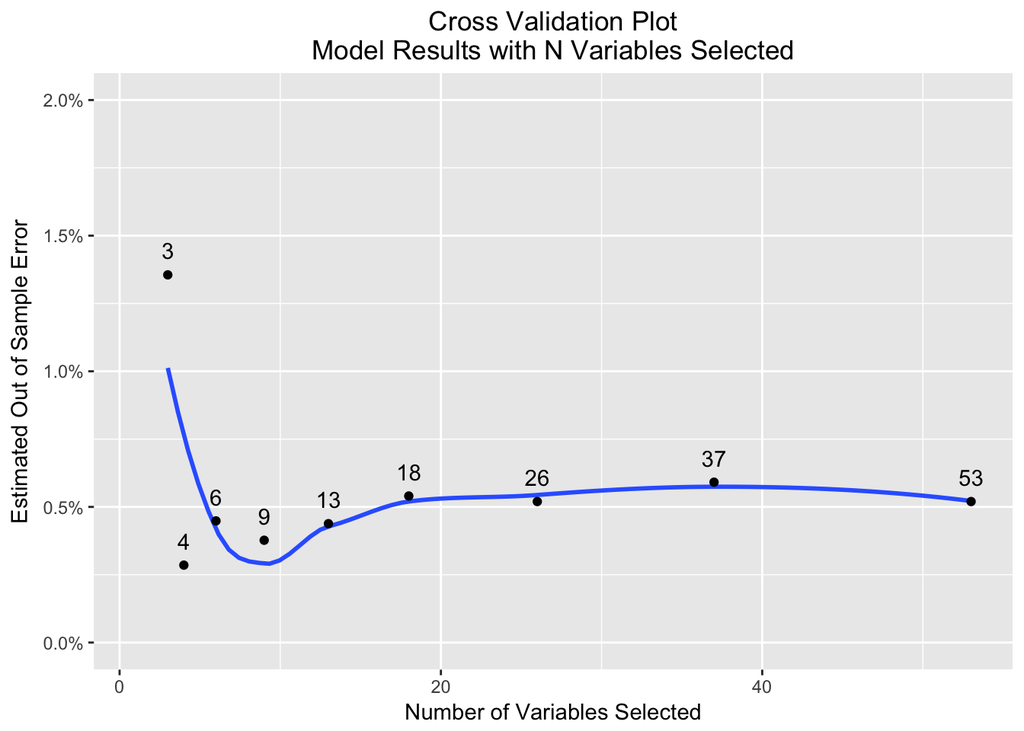

```r
set.seed(12345)
cv <- rfcv(training[,-ncol(training)],training[,ncol(training)],cv.fold = 10, scale = "log",step = .7)
feature_quant <- cbind.data.frame(cv$n.var,cv$error.cv)
names(feature_quant) <- c("num_var","error")

ggplot(data = feature_quant,mapping = aes(x = num_var, y = error)) +
  geom_smooth(method = "loess",se = FALSE) +
  geom_point() +
  scale_y_continuous(labels = percent, limits = c(0,.02)) +
  ggtitle("Cross Validation Plot\nModel Results with N Variables Selected") +
  labs(x = "Number of Variables Selected",y = "Estimated Out of Sample Error") +
  theme(plot.title = element_text(hjust = 0.5)) +
  geom_text(mapping = aes(label = as.factor(num_var)),vjust = -1)
```

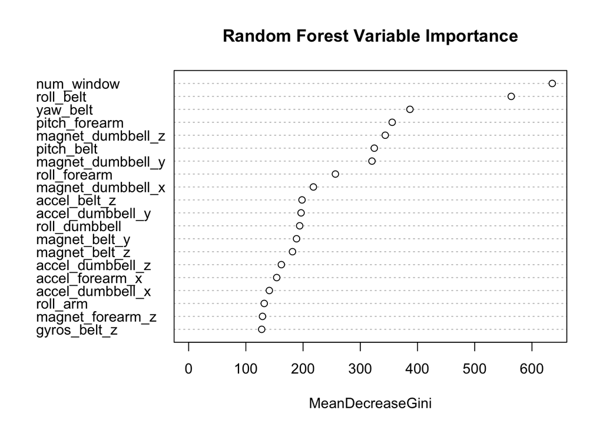

```r
varImpPlot(rf, main = "Random Forest Variable Importance",n.var = 20)
```

## Evaluating the Results

```r
predictions <- predict(rf,newdata = testing)
classe <- testing$classe
confusionMatrix(classe,predictions)
```

```
## Confusion Matrix and Statistics
##
##           Reference
## Prediction    A    B    C    D    E
##          A 2790    0    0    0    0
##          B   13 1885    0    0    0
##          C    0    8 1703    0    0
##          D    0    0   25 1583    0
##          E    0    0    0    1 1802
##
## Overall Statistics
##
##                Accuracy : 0.9952
##                  95% CI : (0.9936, 0.9965)
##     No Information Rate : 0.2857
##     P-Value [Acc > NIR] : < 2.2e-16
##
##                   Kappa : 0.9939
##  Mcnemar's Test P-Value : NA
##
## Statistics by Class:
##
##                      Class: A Class: B Class: C Class: D Class: E
## Sensitivity            0.9954   0.9958   0.9855   0.9994   1.0000
## Specificity            1.0000   0.9984   0.9990   0.9970   0.9999
## Pos Pred Value         1.0000   0.9932   0.9953   0.9845   0.9994
## Neg Pred Value         0.9981   0.9990   0.9969   0.9999   1.0000
## Prevalence             0.2857   0.1930   0.1761   0.1615   0.1837
## Detection Rate         0.2844   0.1922   0.1736   0.1614   0.1837
## Detection Prevalence   0.2844   0.1935   0.1744   0.1639   0.1838
## Balanced Accuracy      0.9977   0.9971   0.9923   0.9982   0.9999
```

The confusion matrix is better visualized with this chart.

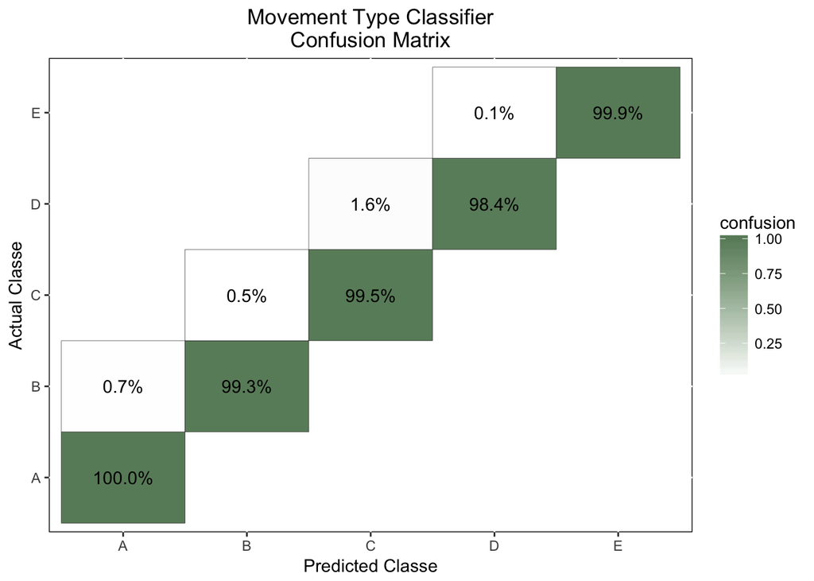

```r
mat <- cbind.data.frame(classe,predictions)
summed <- mat %>% group_by(classe) %>% summarise(total = n()) %>% mutate(new_classe = classe)
new_mat <- mat %>%
  group_by(classe,predictions) %>%
  summarise(counts = n()) %>%
  left_join(summed,by = c("classe"="new_classe")) %>%
  mutate(confusion = counts/total) %>%
  select(classe,predictions,confusion)

#Plot the confusion matrix.
ggplot(data = new_mat,mapping = aes(x = predictions, y = classe,fill = confusion)) +
  geom_tile(color = 'black') + scale_fill_gradient(low = "white",high = "darkseagreen4") +
  geom_text(stat = "identity",mapping = aes(label = scales::percent(confusion))) +
  theme(panel.background = element_rect(fill = "white",colour = "black"), plot.title = element_text(hjust = 0.5)) +
  labs(x = "Predicted Classe", y = "Actual Classe") +
  ggtitle("Movement Type Classifier\nConfusion Matrix")
```

## Conclusion

The random forest performs ably to predict motion type based on sensor data.